```python
from IPython.display import Image
```

# Linear Programming - Theory

## Linear Programming (LP) - Introduction

Linear programming, also known as linear optimization, is a mathematical programming technique to obtain the optimal outcome in a mathematical model whose requirements are represented by linear relationships.

This is particularly useful for framing business problems. Often times, an organization is looking to either minimize something (e.x. cost) or to maximize something (e.x. profit).

Linear programs are broken down into three primary components:

- **Objective Function**: This is a function that describes the main goal of a problem and specifies whether or not we are trying to minimize or maximize
- **Decision Variables**: These are the factors used to decide the output and represent the unknowns of the model. When the model is run to completion, we will know the value of the decision variables
- **Constraints**: Restrictions on the decision variables, decscribed as linear relationships

We aim to interpret a business problem into the above terms.

## LP Example

Problem from "Introduction to Mathematical Programming" by Winston and Venkataran

FarmX must determine how many acres of corn and wheat to plant in 2021.

- An acre of corn yields 10 bushels of corn and requires 4 hours of labor per week
- An acre of wheat yields 25 bushels of wheat and requires 10 hours of labor per week
- Wheat can be sold at \$4/bushel
- Corn can be sold at \$3/bushel
- FarmX has seven acres of land and 40 hours of labor per week available
- The government mandates that at least 30 bushels of corn be produced in 2021

Formulate an LP to tell FarmX how to maximize revenue from wheat and corn.

### Step 1: Define Decision Variables

The unknown variables are how many acres of corn should be planted and how many acres of wheat should be planted.

Let's define our decision variables as:

- $x_1$ = # of acres of wheat planted
- $x_2$ = # of acres of corn planted

### Step 2: Define Objective Function

Our goal is to maximize revenue from wheat and corn. How can we describe revenue earned in terms of $x_1$ and $x_2$?

- We can frame this as (Money earned per bushel)*(Number of bushels)*(Bushels per acre) for both corn and wheat and then sum them

The objective function then becomes:

- $max_{x_1,x_2}\:4\cdot25x_1 + 3\cdot10x_2$

Which means that we are looking for the values of $x_1$ and $x_2$ which maximize the above function

### Step 3: Define Constraints

Each constraint is a linear relationship that can be interpreted to the context of the business problem.

**Land Capacity**: $x_1 + x_2 \leq 7$

- We can have up to seven acres total
- Total acres is just the sum of $x_1$ and $x_2$

**Labor Capacity**: $10x_1 + 4x_2 \leq 40$

- We can have up to forty hours of labor completed per week
- Total number of hours of labor is a sum of how much time it takes to yield an output from the acres of corn and wheat planted

**Government Regulation**: $10x_2 \geq 30$

- We must have at least 30 bushels of corn
- There are 10 bushels of corn produced per acre of corn

**Non-Negativity**: $x_1,x_2 \geq 0$

- We specify that the number of acres should be non-negative
- This is a common constraint that should almost always be included

### Step 4: Write Out Full Linear Program

$max_{x_1,x_2}\:4\cdot25x_1 + 3\cdot10x_2$

$s.t.$

$x_1 + x_2 \leq 7$

$10x_1 + 4x_2 \leq 40$

$10x_2 \geq 30$

$x_1,x_2 \geq 0$

### Step 5: Solve

The easiest way to solve a linear programming problem is graphically. The constraints in the linear program define a **feasible region** where solutions can actually exist. The optimal outcome will be found in one of the corner points.

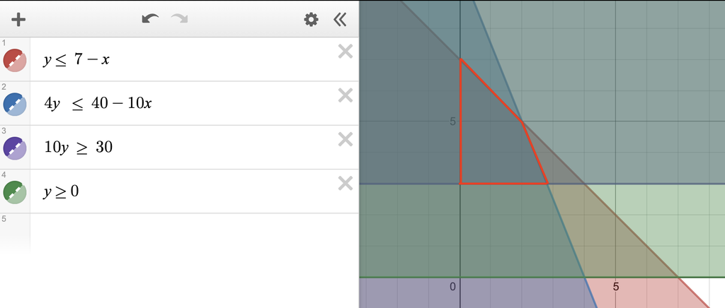

```python
Image("img/example_graphed.png")
```

The space inside the red region consists of all the values of $x_1$ (here referred to as $x$) and $x_2$ (here referred to as $y$) that do not break the constraints of the linear program.

The optimal outcome in a feasible region is always one of the corner points.

Here, we have four corner points representing $(x_1,x_2)$:

- (0,7)
- (2,5)
- (0,3)
- (2.8,3)

Let's plug each of these into the objective function:

- $4\cdot 25(0) + 3\cdot 10(7) = 210$
- $4\cdot 25(2) + 3\cdot 10(5) = 350$
- $4\cdot 25(0) + 3\cdot 10(3) = 90$
- $4\cdot 25(2.8) + 3\cdot 10(3) = 370$

The fourth solution yields the greatest outcome, so the optimal answer is:

- $x_1 =$ 2.8 acres of wheat planted
- $x_2 =$ 3 acres of corn planted

## Linear Simplex

The graphical method is really only practical in simple cases. In practice, linear programs are completed through the **linear simplex method**, which is an efficient way of solving linear programs (though it is quite tedious to do by hand).

I will not go in-depth on each step of the linear simplex method, however at a high level it works as follows:

- Place a linear program into **standard form** and put it into a tableau
- Perform successive pivot operations which each give a basic feasible solution, based on which pivot will most improve the solution
- Continue until no more pivots can be completed

[Here](https://people.richland.edu/james/ictcm/2006/simplex.html) is a link that describes the full procedure for the linear simplex quite well.

## Standard Form

Suppose we hav $n$ variables and $m$ equality constraints.

The standard form in matrix notation is:

$maximize_x \: c^\intercal x$

$subject to$

$Ax = b$

$x \geq 0$

Here, $A$ is an $m$ by $n$ matrix, $c$ is an $n$-vector and $b$ is an $m$-vector

To convert an LP into standard form, there are four main cases that require conversion:

- **Case 1**: Objective has min instead of max
- **Case 2**: There is a free or unrestricted (URS) variable
- **Case 3**: There is an inequality constraint
- **Case 4**: There are non-positive variables

### Case 1

- Multiply the objecive function by $-1$ to convert it from minimization to maximation
  - $minimize_x \:c^\intercal x$ is equivalent to
  - $maximize_x \: -c^\intercal x$

### Case 2

- A free or unrestricted variable is a variable that has no constraint on its value
- Split up the free variable into a left and right variable and set non-negativity constraints on those variables

Example: Suppose we have a free variable $x_j$

We can transform this into:

- $x_j = x_j^+ - x_j^-$
- $x_j^+ \geq 0$
- $x_j^- \geq 0$

Now we have imposed constraints while keeping the variable equivalent.

### Case 3

For the case where the right-hand side is positive and we have a $\leq$ constraint...

- Introduce a **slack** variable $s$ -- this is what the pivot operations in the linear simplex are based off
- Slack describes how much "unused resource" or "wiggle room" we have in a constraint
- We want to bring all slack down to zero to get the tightest fit we can (this is equivalent to finding the optimal corner point in the feasible region)
  - In fact, when the slack of a constraint is brought down to zeor, we call it a **tight** constraint

Example: Suppose we have an inequality constraint

- $x_1 - 4x_2 + x_3 \leq 10$

We can turn this into an equality constraint by adding a slack variable $s$:

- $x_1 - 4x_2 + x_3 + s = 10$
- $s \geq 0$

Note that the slack variables also follow non-negativity!

For the case where the right-hand side is positive and we have a $\geq$ constraint...

But first, what if the right-hand-side is negative?

- $-2x_1 - 4x_2 + x_3 + x_4 \leq -1$
- Here we cannot just add a slack
- We need a positive right hand side
- So, we first multiply by -1 to get:
  - $2x_1 + 4x_2 - x_3 - x_4 \geq 1$

No, we have right-hand side that is positive with a $\geq$ constraint.

To turn this into an equality, we add a **surplus** variable $s_2$

- $2x_1 + 4x_2 - x_3 - x_4 - s_2 = 1$
- This is the inverse of a slack variable
- A surplus variable measure the amount by which the left-hand side exceeds the right-hand side

### Case 4

Suppose we have a constraint $x_2 \leq 0$

- Define a variable $y_2 = -x_2$ and set $y_2 \geq 0$
- Replace all instances of $x_2$ in the LP with $y_2$

## Integer Programming (IP)

Integer programming is a case in LPs where we cannot have fractional solutions. Instead, we must consider the optimization problem:

$Maximize \sum_{j=1}^{n}c_jx_j$

subject to:

$\sum_{j=1}^{n}a_{ij}x_j=b_i \:\:(i=1,2,...,m),$

$x_j\geq0 \:\: (j = 1,2,...,n),$

$x_j\:integer \:\:(for\:some\:or\:all\:j=1,2,...,n)$

In this case, we have a **mixed-integer** problem where some, but not, all variables are restricted to an integer.

- A **pure-integer** problem is when all decision variables must be integers

This formulation is quite useful for categorical decision variables.

- A very common type of integer programming problem is one where each variable $x_j$ is binary (1 or 0)
- 1 represents making a decision (e.x. investing in stock $j$)
- 0 represents refraining from said decision (e.x. not investing in stock $j$).

### IP Example

Problem from "Applied Mathematical Programming" by Bradley, Hax, and Magnanti

Suppose we have a capital-budgeting problem where we have $j$ potential items to invest in. For each item, we either buy or don't buy.

**Decision variable:** $x_j$ = 0 or 1, indicating that the $j$-the investment is either rejected or accepted.

Let's describe the contribution of each $j$ investment as $c_j$ and the amount of resource $i$ used on investment $j$ as $a_ij$.

Now, we can write this problem as:

$ Maximize \sum_{j=1}^{n}c_jx_j,$

subject to:

$\sum_{j=1}^{n}a_{ij}x_j \leq b_i \:\: (i = 1,2,...,m),$

$x_j =\{0,1\} \:\: (j = 1,2,...,n)$

Here, we are aiming to maximize the total contribution of all investments without exceeding the limited availability $b_i$ of a resource.

## How to Get Better at Formulating LPs and IPs

While we went through more of the theory, in practice we will use tools such as Excel Solver or Python/R libraries to solve LPs and IPs. In these cases, what is most important is that we formulate the LP and IP (as we did in each example) appropriately.

The best way to get better at formulating LPs is just through practice. However, the general thought process is what is seen in the **Example**.

## More Resources

[Explanation on converting to standard form](https://ocw.mit.edu/courses/sloan-school-of-management/15-053-optimization-methods-in-management-science-spring-2013/tutorials/MIT15_053S13_tut06.pdf)

[Linear Simplex Exlanation, In-Depth](https://people.richland.edu/james/ictcm/2006/simplex.html)

[Linear Programming Examples](https://www.superprof.co.uk/resources/academic/maths/linear-algebra/linear-programming/linear-programming-examples.html)

[Integer Programming, In-Depth](http://web.mit.edu/15.053/www/AMP-Chapter-09.pdf)